# Text Mining

The content in this course has focused on numeric data. This is mainly because most of the data the average data scientist works with is numeric. However, today more and more text data is being collected and knowing even some basic text mining terminology and techniques like sentiment analysis go a long way. Here, we will see a brief introduction to text data structure and simple text mining. For more details about basic text mining in R, see the freely available book [Text Mining with R](https://www.tidytextmining.com/index.html) by Julia Silge and David Robinson (2 of the people I recommended following on Twitter (X) the first day of class). All of the code for this lecture has been adapted from their book.

## Tidy Text

Similar to how we defined tidy data in the data wrangling lectures, here we define the tidy text format as being a table with **one-token-per-row**. A **token** is a meaningful unit of text, such as a word (but could also be a sentence, n-gram, etc.), that we are interested in using for analysis, and **tokenization** is the process of splitting text into tokens. If we structure our text data into this tidy format we will be able to use the pipe, ggplot2, and all other functions/packages created for tidy data.

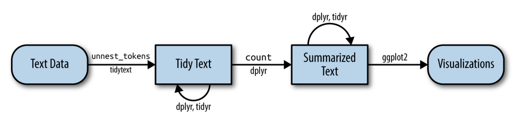

Note: all of the packages needed to run the code in this file are listed below. Be sure you have installed each of them before trying to load them. Most are new packages we haven’t used in the course before.

### (Optional) Installation chunk

```r
install.packages(c(
  "textdata", "dplyr", "stringr", "janeaustenr", "ggplot2",
  "gutenbergr", "scales", "tidyr", "tidytext",
  "RColorBrewer", "wordcloud", "reshape2", "forcats", "tibble"
))

# If gutenbergr from CRAN gives mirror/download issues, install the dev version:
# remotes::install_github("ropensci/gutenbergr")
```

### Load packages

```r
library(textdata)
library(dplyr)
library(stringr)
library(janeaustenr)
library(ggplot2)
library(gutenbergr)
library(scales)
library(tidyr)
library(tidytext)
library(RColorBrewer)
library(wordcloud)
library(reshape2)
library(forcats)
library(tibble)

# For reproducible wordclouds
set.seed(1234)
```

Let’s use the text of Jane Austen’s 6 completed, published novels from the `janeaustenr` package (Silge 2016), and transform them into a tidy format. The `janeaustenr` package provides these texts in a one-row-per-line format, where a line in this context is analogous to a literal printed line in a physical book. Let’s start with that, and also use `mutate()` to annotate a `linenumber` quantity to keep track of lines in the original format and a chapter (using a regular expression, aka regex) to find where all the chapters are.

```r
original_books <- austen_books() %>%
  group_by(book) %>%
  mutate(
    linenumber = row_number(),
    chapter = cumsum(str_detect(
      text,
      regex("^chapter [\\divxlc]", ignore_case = TRUE)
    ))
  ) %>%
  ungroup()

original_books
```

```
## # A tibble: 73,422 × 4
##    text                    book                linenumber chapter
##    <chr>                   <fct>                    <int>   <int>
##  1 "SENSE AND SENSIBILITY" Sense & Sensibility          1       0
##  2 ""                      Sense & Sensibility          2       0
##  3 "by Jane Austen"        Sense & Sensibility          3       0
##  4 ""                      Sense & Sensibility          4       0
##  5 "(1811)"                Sense & Sensibility          5       0
##  6 ""                      Sense & Sensibility          6       0
##  7 ""                      Sense & Sensibility          7       0
##  8 ""                      Sense & Sensibility          8       0
##  9 ""                      Sense & Sensibility          9       0
## 10 "CHAPTER 1"             Sense & Sensibility         10       1
## # ℹ 73,412 more rows
```

To work with this as a tidy dataset, we need to restructure it in the one-token-per-row format, which can be done with the `unnest_tokens()` function.

The two basic arguments to `unnest_tokens` used here are column names. First we have the output column name that will be created as the text is unnested into it (`word`, in this case), and then the input column that the text comes from (`text`, in this case).

After using `unnest_tokens` note:

- Other columns, such as the line number each word came from, are retained.
- Punctuation has been stripped.
- By default, `unnest_tokens()` converts the tokens to lowercase, which makes them easier to compare or combine with other datasets. (Use the `to_lower = FALSE` argument to turn off this behavior).

```r
tidy_books <- original_books %>%
  unnest_tokens(word, text)

tidy_books
```

```
## # A tibble: 725,055 × 4
##    book                linenumber chapter word
##    <fct>                    <int>   <int> <chr>
##  1 Sense & Sensibility          1       0 sense
##  2 Sense & Sensibility          1       0 and
##  3 Sense & Sensibility          1       0 sensibility
##  4 Sense & Sensibility          3       0 by
##  5 Sense & Sensibility          3       0 jane
##  6 Sense & Sensibility          3       0 austen
##  7 Sense & Sensibility          5       0 1811
##  8 Sense & Sensibility         10       1 chapter
##  9 Sense & Sensibility         10       1 1
## 10 Sense & Sensibility         13       1 the
## # ℹ 725,045 more rows
```

Now that the data is in one-word-per-row format, we can manipulate it with tidy tools like `dplyr`. Often in text analysis, we will want to remove **stop words**. Stop words are words that are not useful for an analysis, typically extremely common words such as “the”, “of”, “to”, and so forth in English. We can remove stop words (kept in the tidytext dataset `stop_words`) with an `anti_join()`.

```r
data(stop_words)
head(stop_words)
```

```
## # A tibble: 6 × 2
##   word      lexicon
##   <chr>     <chr>
## 1 a         SMART
## 2 a's       SMART
## 3 able      SMART
## 4 about     SMART
## 5 above     SMART
## 6 according SMART
```

```r
tidy_books <- tidy_books %>%
  anti_join(stop_words, by = "word")
```

We can also use dplyr’s `count()` to find the most common words in all the books as a whole.

```r
tidy_books %>%
  count(word, sort = TRUE)
```

```
## # A tibble: 13,914 × 2
##    word       n
##    <chr>  <int>
##  1 miss    1855
##  2 time    1337
##  3 fanny    862
##  4 dear     822
##  5 lady     817
##  6 sir      806
##  7 day      797
##  8 emma     787
##  9 sister   727
## 10 house    699
## # ℹ 13,904 more rows
```

Because we’ve been using tidy tools, our word counts are stored in a tidy data frame. This allows us to pipe this directly to the `ggplot` function and to create a visualization of the most common words.

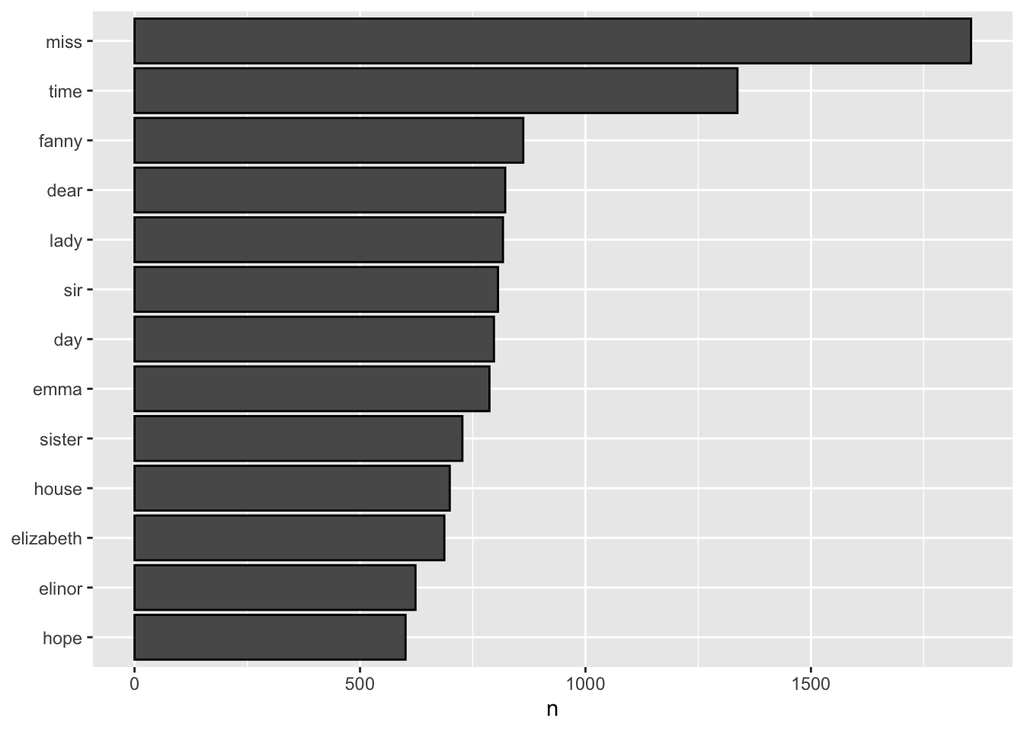

```r
tidy_books %>%
  count(word, sort = TRUE) %>%
  filter(n > 600) %>%
  mutate(word = reorder(word, n)) %>%
  ggplot(aes(n, word)) +
  geom_col(color = "black") +
  labs(y = NULL)
```

## Word Frequencies

A common task in text mining is to look at word frequencies, just like we have done above for Jane Austen’s novels, and to compare frequencies across different texts. We can do this intuitively and smoothly using tidy data principles. We already have Jane Austen’s works; let’s get two more sets of texts to compare to. We will use the `gutenbergr` package.

The `gutenbergr` package provides access to the public domain works from the [Project Gutenberg](https://www.gutenberg.org/) collection. The package includes tools both for downloading books (stripping out the unhelpful header/footer information), and a complete dataset of Project Gutenberg metadata that can be used to find works of interest.

We can access these works using `gutenberg_download()` and the [Project Gutenberg ID](https://www.gutenberg.org/browse/scores/top) numbers for each novel.

Let’s look at two Charles Dickens books:

1. *A Christmas Carol* (Project Gutenberg ID: 19337)
2. *Oliver Twist* (Project Gutenberg ID: 730)

```r
dickens <- gutenberg_download(
  c(19337, 730),
  meta_fields = "title",
  mirror = "http://mirror.csclub.uwaterloo.ca/gutenberg"
)

head(dickens)
```

```
## # A tibble: 6 × 3
##   gutenberg_id text                     title
##          <int> <chr>                    <chr>
## 1        19337 "A CHRISTMAS CAROL"      A Christmas Carol
## 2        19337 ""                       A Christmas Carol
## 3        19337 "By CHARLES DICKENS"     A Christmas Carol
## 4        19337 ""                       A Christmas Carol
## 5        19337 "ILLUSTRATED BY"         A Christmas Carol
## 6        19337 "GEORGE ALFRED WILLIAMS" A Christmas Carol
```

We again use `unnest_tokens` and remove stop words.

```r
tidy_dickens <- dickens %>%
  unnest_tokens(word, text) %>%
  anti_join(stop_words, by = "word")
```

Here are the most common words in these two novels:

```r
tidy_dickens %>%
  count(word, sort = TRUE)
```

```
## # A tibble: 11,049 × 2
##    word          n
##    <chr>     <int>
##  1 oliver      766
##  2 replied     482
##  3 time        401
##  4 bumble      366
##  5 sikes       346
##  6 gentleman   337
##  7 scrooge     327
##  8 boy         323
##  9 dear        303
## 10 jew         296
## # ℹ 11,039 more rows
```

Now let’s get some well-known works of the Brontë sisters, whose lives overlapped with Jane Austen’s somewhat but who wrote in a rather different style.

1. *Jane Eyre* (Project Gutenberg ID: 1260)
2. *Wuthering Heights* (Project Gutenberg ID: 768)

```r
bronte <- gutenberg_download(
  c(1260, 768),
  mirror = "http://mirror.csclub.uwaterloo.ca/gutenberg"
)

head(bronte)
```

```
## # A tibble: 6 × 2
##   gutenberg_id text
##          <int> <chr>
## 1         1260 "JANE EYRE"
## 2         1260 "AN AUTOBIOGRAPHY"
## 3         1260 ""
## 4         1260 "by Charlotte Brontë"
## 5         1260 ""
## 6         1260 "_ILLUSTRATED BY F. H. TOWNSEND_"
```

We again use `unnest_tokens` and remove stop words.

```r
tidy_bronte <- bronte %>%
  unnest_tokens(word, text) %>%
  anti_join(stop_words, by = "word")
```

Here are the most common words in these two novels:

```r
tidy_bronte %>%
  count(word, sort = TRUE)
```

```
## # A tibble: 15,328 × 2
##    word           n
##    <chr>      <int>
##  1 miss         439
##  2 heathcliff   421
##  3 time         372
##  4 sir          359
##  5 linton       346
##  6 jane         341
##  7 catherine    337
##  8 day          337
##  9 don’t        335
## 10 house        324
## # ℹ 15,318 more rows
```

It looks like the word “time” is one of the most common words across all three authors.

Now let’s calculate the frequency for each word for the works of the three authors by binding the data frames together. We can use `pivot_wider()` and `pivot_longer()` from `tidyr` to reshape our data frame so that it is just what we need for plotting and comparing the three sets of novels.

We use `str_extract()` here because the UTF-8 encoded texts from Project Gutenberg have some examples of words with underscores around them to indicate emphasis (like italics). The tokenizer treated these as words, but we don’t want to count “*any*” separately from “any” as we saw in our initial data exploration before choosing to use `str_extract()`.

```r
frequency <- bind_rows(
  mutate(tidy_bronte,  author = "Brontë Sisters"),
  mutate(tidy_dickens, author = "Charles Dickens"),
  mutate(tidy_books,   author = "Jane Austen")
) %>%
  mutate(word = str_extract(word, "[a-z']+")) %>%
  count(author, word) %>%
  group_by(author) %>%
  mutate(proportion = n / sum(n)) %>%
  ungroup() %>%
  select(-n) %>%
  pivot_wider(names_from = author, values_from = proportion) %>%
  pivot_longer(
    cols = c(`Brontë Sisters`, `Charles Dickens`),
    names_to = "author",
    values_to = "proportion"
  )

head(frequency)
```

```
## # A tibble: 6 × 4
##   word    `Jane Austen` author           proportion
##   <chr>           <dbl> <chr>                 <dbl>
## 1 a          0.00000919 Brontë Sisters   0.000121
## 2 a          0.00000919 Charles Dickens NA
## 3 abaht     NA          Brontë Sisters   0.00000934
## 4 abaht     NA          Charles Dickens NA
## 5 abandon   NA          Brontë Sisters   0.0000374
## 6 abandon   NA          Charles Dickens  0.0000148
```

Let’s make the plot. Note that we surround the `Jane Austen` column name with backticks since it is a non-standard variable name - it has a space between the two names, which R doesn’t like. You could get around this by naming the variable `Jane_Austen`, for example.

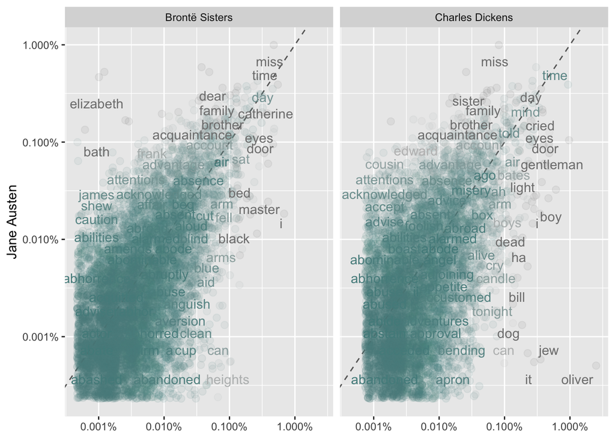

```r
frequency %>%
  ggplot(aes(x = proportion, y = `Jane Austen`,
             color = abs(`Jane Austen` - proportion))) +
  geom_abline(color = "gray40", linetype = 2) +
  geom_jitter(alpha = 0.1, size = 2.5, width = 0.3, height = 0.3) +
  geom_text(aes(label = word), check_overlap = TRUE, vjust = 1.5) +
  scale_x_log10(labels = percent_format()) +
  scale_y_log10(labels = percent_format()) +
  scale_color_gradient(
    limits = c(0, 0.001),
    low = "darkslategray4", high = "gray75"
  ) +
  facet_wrap(~author, ncol = 2) +
  theme(legend.position = "none") +
  labs(y = "Jane Austen", x = NULL)
```

Overall, notice that the words in the Austen-Brontë panel are closer to the zero-slope line than in the Austen-Dickens panel. Also notice that the words extend to lower frequencies in the Austen-Brontë panel; there is empty space in the Austen-Dickens panel at low frequency. These characteristics indicate that Austen and the Brontë sisters use more similar words than Austen and Dickens.

Let’s quantify how similar and different these sets of word frequencies are using a correlation test. How correlated are the word frequencies between Austen and the Brontë sisters, and between Austen and Dickens?

```r
cor.test(
  data = frequency[frequency$author == "Brontë Sisters", ],
  ~ proportion + `Jane Austen`
)
```

```
##
##  Pearson's product-moment correlation
##
## data:  proportion and Jane Austen
## t = 85.902, df = 8325, p-value < 2.2e-16
## alternative hypothesis: true correlation is not equal to 0
## 95 percent confidence interval:
##  0.6739246 0.6967023
## sample estimates:
##       cor
## 0.6854811
```

```r
cor.test(
  data = frequency[frequency$author == "Charles Dickens", ],
  ~ proportion + `Jane Austen`
)
```

```
##
##  Pearson's product-moment correlation
##
## data:  proportion and Jane Austen
## t = 47.473, df = 6804, p-value < 2.2e-16
## alternative hypothesis: true correlation is not equal to 0
## 95 percent confidence interval:
##  0.4807545 0.5164532
## sample estimates:
##       cor
## 0.4988154
```

Just as we saw in the plots, the word frequencies are more correlated between the Austen and Brontë novels than between Austen and Dickens.